# Análisis multivariante

Grupo 2.4

2025-02-23

# CLUSTERING JERÁRQUICO

```r
library(readr)
StudentPerformanceFactors <-read_csv("StudentPerformanceFactors_1.csv")


tipos <- sapply(StudentPerformanceFactors, class)
```

```r
### Ahora escogemos el tipo de las variables
tipos <- sapply(StudentPerformanceFactors, class)
varNum <- names(tipos)[tipos %in% c("integer", "numeric")]
varCat <- names(tipos)[tipos %in% c("factor", "character")]
varCat<-varCat[-14]
dataNum <- StudentPerformanceFactors[, varNum]
```

## Jerárquico numérico

Implementamos diferentes algoritmos de clustering jerárquico empleando la distancia euclídea para medir la proximidad entre los datos y estructurar los grupos.

```r
## Calculamos las distancias
### Euclidean
distancia <- dist(dataNum, method = "euclidean")

## Generamos la agrupación
### single
agrSingle_num <- hclust(distancia, method = "single")

### complete
agrComplete_num <- hclust(distancia, method = "complete")

### average
agrAverage_num <- hclust(distancia, method = "average")

### mcquitty
agrMcquitty_num <- hclust(distancia, method = "mcquitty")

### median
agrMedian_num <- hclust(distancia, method = "median")

### centroid
agrCentroid_num <- hclust(distancia, method = "centroid")

### ward.D o ward.D2
agrWard_num <- hclust(distancia, method = "ward.D2")
```

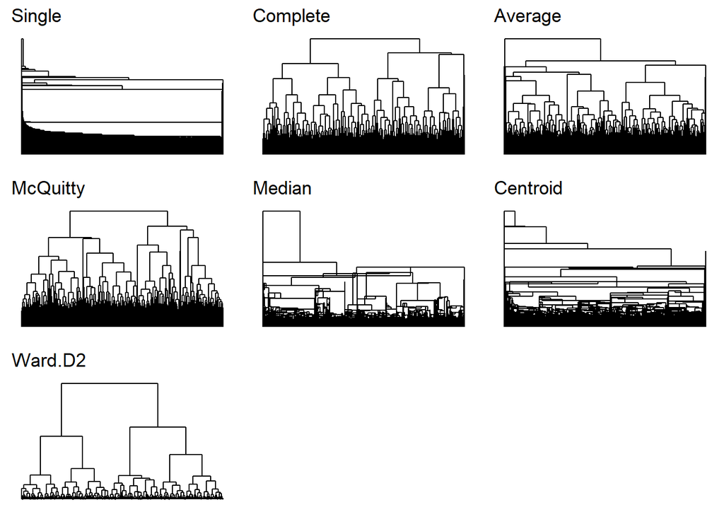

```r
## Graficamos el dendograma ----------------------------------------------------
library(ggplot2)
library(ggdendro)
library(gridExtra)
### Función para convertir hclust a ggplot
plot_dendrogram <- function(hclust_obj, method_name) {
  dendro_data <- ggdendro::dendro_data(hclust_obj)
  ggplot(ggdendro::segment(dendro_data)) +
    geom_segment(aes(x = x, y = y, xend = xend, yend = yend)) +
    theme_minimal() +
    ggtitle(method_name) +
    theme(axis.text = element_blank(),
          axis.ticks = element_blank(),
          axis.title = element_blank(),
          panel.grid = element_blank())
}

### Lista de dendrogramas con nombres
dendrograms <- list(
  plot_dendrogram(agrSingle_num, "Single"),
  plot_dendrogram(agrComplete_num, "Complete"),
  plot_dendrogram(agrAverage_num, "Average"),
  plot_dendrogram(agrMcquitty_num, "McQuitty"),
  plot_dendrogram(agrMedian_num, "Median"),
  plot_dendrogram(agrCentroid_num, "Centroid"),
  plot_dendrogram(agrWard_num, "Ward.D2")
)

### Mostrar todos los dendrogramas en una cuadrícula
gridExtra::grid.arrange(grobs = dendrograms, ncol = 3)
```

Evaluación de la calidad del clustering con la correlación cofenética.

```r
# Calculate correlation --------------------------------------------------------
info <- data.frame(metricas = c("Single", "Complete", "Average", "McQuitty", "Median",
                        "Centroid", "Ward"),
           correlaciones = c(cor(distancia, cophenetic(agrSingle_num)),
                             cor(distancia, cophenetic(agrComplete_num)),
                             cor(distancia, cophenetic(agrAverage_num)),
                             cor(distancia, cophenetic(agrMcquitty_num)),
                             cor(distancia, cophenetic(agrMedian_num)),
                             cor(distancia, cophenetic(agrCentroid_num)),
                             cor(distancia, cophenetic(agrWard_num))))

(info <- info[order(info$correlaciones, decreasing = T), ])
```

```
##   metricas correlaciones
## 3  Average     0.5934875
## 6 Centroid     0.5924009
## 7     Ward     0.5859970
## 2 Complete     0.5731776
## 4 McQuitty     0.5558066
## 5   Median     0.4069461
## 1   Single     0.1722219
```

Descartamos los métodos de agregación median y single, ya que presentan un rendimiento inferior. Entre los restantes, average y centroid destacan como las mejores opciones, aunque las diferencias con ward, complete y mcquitty no son significativas.

## Jerárquico mixto

### Clustering

```r
# Calculamos la matriz de disimilitud utilizando el índice de Gower
StudentPerformanceFactors[varCat] <- lapply(StudentPerformanceFactors[varCat], as.factor)
dissimMatrix <- daisy(StudentPerformanceFactors[, c(varNum, varCat)], metric = "gower", stand = TRUE)
# Convertimos las variables categóricas para evitar problemas
for (vC in varCat) {StudentPerformanceFactors[, vC] <- as.factor(as.character(StudentPerformanceFactors[, vC]))}
dissimMatrix <- daisy(StudentPerformanceFactors[, c(varNum, varCat)], metric = "gower", stand = TRUE)

##Elevar la matriz de disimilitud al cuadrado ayuda a que cumpla con las propiedades de una distancia métrica.
distMatrix <- dissimMatrix^2

## Generamos la agrupación
### single
agrSingle <- hclust(distMatrix, method = "single")
### complete
agrComplete <- hclust(distMatrix, method = "complete")
### average
agrAverage <- hclust(distMatrix, method = "average")
### mcquitty
agrMcquitty <- hclust(distMatrix, method = "mcquitty")
### median
agrMedian <- hclust(distMatrix, method = "median")
### centroid
agrCentroid <- hclust(distMatrix, method = "centroid")
### ward.D o ward.D2
agrWard <- hclust(distMatrix, method = "ward.D2")
```

### Dendogramas

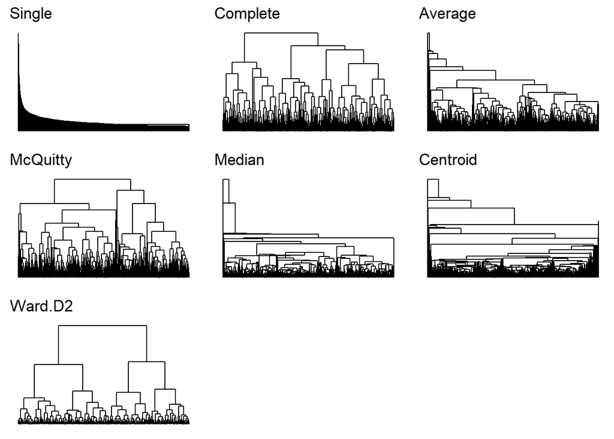

```r
### Lista de dendrogramas con nombres
dendrograms <- list(
  plot_dendrogram(agrSingle, "Single"),
  plot_dendrogram(agrComplete, "Complete"),
  plot_dendrogram(agrAverage, "Average"),
  plot_dendrogram(agrMcquitty, "McQuitty"),
  plot_dendrogram(agrMedian, "Median"),
  plot_dendrogram(agrCentroid, "Centroid"),
  plot_dendrogram(agrWard, "Ward.D2")
)

### Mostrar todos los dendrogramas en una cuadrícula
gridExtra::grid.arrange(grobs = dendrograms, ncol = 3)
```

### Métricas

```r
# Calculate correlation --------------------------------------------------------
info <- data.frame(metricas = c("Single", "Complete", "Average", "McQuitty", "Median",
                        "Centroid", "Ward"),
           correlaciones = c(cor(distMatrix, cophenetic(agrSingle)),
                             cor(distMatrix, cophenetic(agrComplete)),
                             cor(distMatrix, cophenetic(agrAverage)),
                             cor(distMatrix, cophenetic(agrMcquitty)),
                             cor(distMatrix, cophenetic(agrMedian)),
                             cor(distMatrix, cophenetic(agrCentroid)),
                             cor(distMatrix, cophenetic(agrWard))))

(info <- info[order(info$correlaciones, decreasing = T), ])
```

```
##   metricas correlaciones
## 3  Average     0.4080307
## 6 Centroid     0.3865901
## 1   Single     0.3637295
## 7     Ward     0.3471350
## 5   Median     0.2608684
## 4 McQuitty     0.2583062
## 2 Complete     0.2542672
```

Aquí no escogeríamos los métodos *Median*, *McQuitty* o *Complete*, pero sí *Average*, *Centroid*, *Single* o *Ward*; con preferencia por aquellos cuya correlación sea más cercana a 1.

## Cortar dendogramas

```r
### Function suggested level
suggested.level <- function(hc, min = 3, max = 10){
  if(min < 2) stop("Min should be equal or higher than 2")
  intra <- rev(cumsum(hc[["height"]]))
  quot <- intra[min:(max)]/intra[(min - 1):(max - 1)]
  nb.clust <- which.min(quot) + min - 1
  return(nb.clust)
}
```

```r
### Comprobamos el valor que nos devuelve
suggested.level(agrAverage)
```

```
## [1] 3
```

```r
suggested.level(agrCentroid)
```

```
## [1] 3
```

```r
suggested.level(agrSingle)
```

```
## [1] 3
```

```r
suggested.level(agrWard)
```

```
## [1] 3
```

```r
suggested.level(agrMedian)
```

```
## [1] 3
```

```r
suggested.level(agrMcquitty)
```

```
## [1] 3
```

```r
suggested.level(agrComplete)
```

```
## [1] 3
```

```r
suggested.level(agrAverage_num)
```

```
## [1] 3
```

```r
suggested.level(agrCentroid_num)
```

```
## [1] 3
```

```r
suggested.level(agrWard_num)
```

```
## [1] 3
```

```r
suggested.level(agrComplete_num)
```

```
## [1] 3
```

```r
suggested.level(agrMcquitty_num)
```

```
## [1] 3
```

```r
suggested.level(agrMedian_num)
```

```
## [1] 3
```

```r
suggested.level(agrSingle_num)
```

```
## [1] 3
```

Parece ser que, para todos los métodos, el mejor corte es aquel que nos deja con tres clusters distintos.

## Labelling de los clusters

Para comparar los distintos métodos de clustering, analizamos varias métricas que evalúan la calidad de la segmentación obtenida: - **Índice de Dunn (`dunn` y `dunn2`)**  
- Mide la relación entre la distancia mínima entre clusters y el diámetro máximo dentro de los clusters.  
- Un valor más alto indica una mejor compactación y separación de los grupos.

- **Coeficiente de Silueta (`avg.silwidth`)**
  - Evalúa la coherencia interna de los clusters comparando la distancia de cada punto con su propio cluster y con el cluster más cercano.
  - Valores cercanos a 1 indican una mejor agrupación.
- **Índice de Davies-Bouldin (`davies.bouldin`)**
  - Mide la relación entre la dispersión dentro de cada cluster y la separación entre clusters.
  - Cuanto menor sea el valor, mejor será la estructura del clustering.
- **Separación y compactación (`within.cluster.ss`, `between.cluster.ss`)**
  - Cuantifican la dispersión interna dentro de los clusters y la separación entre ellos.
  - Un buen clustering tiene una baja variabilidad dentro de los clusters y una alta variabilidad entre ellos.

### Numérico

```r
k <- 3
(cut_k <- cutree(agrAverage_num, k))
```

```
##    [1] 1 2 1 1 2 1 2 2 2 2 1 2 1 1 1 2 2 1 1 2 1 2 1 1 2 2 1 1 2 2 2 2 1 2 1 1 1
##   [38] 2 1 1 2 2 1 2 2 1 1 2 2 2 2 2 2 1 2 1 1 2 1 2 1 2 1 1 2 1 1 2 2 1 2 2 1 1
##   [75] 2 2 1 2 2 2 1 1 1 2 1 1 1 2 1 2 2 2 1 2 3 1 1 1 2 1 1 2 1 2 1 1 2 2 2 1 1
##  [112] 2 2 3 2 1 2 1 1 1 1 2 1 2 2 1 2 2 2 2 2 1 1 1 1 2 1 2 2 1 2 1 1 1 2 2 1 2
##  [149] 1 2 1 1 2 2 1 1 2 2 1 1 2 1 2 1 2 2 2 1 2 2 1 2 2 2 1 1 2 2 1 2 2 2 1 2 1
##  [186] 2 1 2 2 2 1 2 2 1 2 1 2 2 2 1 2 2 2 2 2 2 2 1 1 3 2 1 2 1 1 1 2 2 2 2 1 2
##  [223] 1 2 1 2 2 1 1 1 2 1 1 2 1 2 1 1 2 2 2 2 2 2 2 2 2 1 1 1 2 2 1 2 1 2 2 2 2
##  [260] 2 2 1 1 1 1 1 2 1 2 2 2 1 1 2 1 1 1 1 1 2 2 2 2 2 1 2 2 1 2 2 2 2 1 1 2 2
##  [297] 2 1 1 2 1 2 1 2 2 1 2 1 1 2 2 2 2 1 2 1 1 2 1 1 2 2 1 1 2 1 1 2 1 1 1 1 2
##  [334] 2 2 2 1 2 2 1 2 2 1 1 1 2 1 2 2 1 2 1 2 1 2 1 1 1 1 2 1 2 2 1 1 2 1 1 1 1
##  [371] 2 2 2 2 1 2 2 1 1 1 2 2 2 1 2 2 1 2 2 1 2 1 2 2 2 1 1 1 1 1 2 2 2 2 2 2 2
##  [408] 1 1 1 2 1 1 2 1 1 1 2 2 2 1 1 2 1 2 1 1 2 2 2 2 1 1 1 2 1 2 2 1 2 2 2 2 2
##  [445] 2 2 2 1 1 2 1 2 2 1 1 2 2 1 1 1 1 1 1 1 1 1 1 2 1 1 2 2 2 1 1 2 2 1 1 2 1
##  [482] 2 1 1 2 2 2 1 2 1 1 1 1 2 2 2 2 1 2 2 1 1 2 1 2 2 2 1 2 2 2 2 2 1 1 2 2 1
##  [519] 2 1 2 2 2 2 2 1 1 2 1 3 2 2 2 2 1 2 2 2 2 2 2 1 1 1 1 1 2 1 2 2 1 2 2 2 2
```

[output cut: 164 more lines]

```r
table(cut_k)
```

```
## cut_k
##    1    2    3
## 2760 3826   21
```

```r
fpc::cluster.stats(distancia, clustering = as.numeric(cut_k))
```

```
## $n
## [1] 6607
##
## $cluster.number
## [1] 3
##
## $cluster.size
## [1] 2760 3826   21
##
## $min.cluster.size
## [1] 21
##
## $noisen
## [1] 0
##
## $diameter
## [1] 57.33236 58.88124 41.54516
##
## $average.distance
## [1] 19.33342 22.17465 21.93712
##
## $median.distance
## [1] 18.68154 21.42429 21.85141
##
## $separation
## [1] 2.000000 2.000000 4.472136
##
## $average.toother
## [1] 30.95820 31.01263 38.17297
##
## $separation.matrix
##          [,1]     [,2]     [,3]
## [1,] 0.000000 2.000000 4.472136
## [2,] 2.000000 0.000000 4.582576
## [3,] 4.472136 4.582576 0.000000
##
## $ave.between.matrix
##          [,1]     [,2]     [,3]
## [1,]  0.00000 30.93838 34.57018
## [2,] 30.93838  0.00000 40.77194
```

[output cut: 53 more lines]

```
##
## $cwidegap
## [1] 17.88854 11.04536 13.00000
##
## $widestgap
## [1] 17.88854
##
## $sindex
## [1] 3.49389
##
## $corrected.rand
## NULL
##
## $vi
## NULL
```

```r
k <- 3
(cut_k <- cutree(agrCentroid_num, k))
```

```
##    [1] 1 1 1 1 1 1 1 1 1 1 1 1 1 1 1 1 1 1 1 1 1 1 1 1 1 1 1 1 1 1 1 1 1 1 1 1 1
##   [38] 1 1 1 1 1 1 1 1 1 1 1 1 1 1 1 1 1 1 1 1 1 1 1 1 1 1 1 1 1 1 1 1 1 1 1 1 1
##   [75] 1 1 1 1 1 1 1 1 1 1 1 1 1 1 1 1 1 1 1 1 1 1 1 1 1 1 1 1 1 1 1 1 1 1 1 1 1
##  [112] 1 1 1 1 1 1 1 1 1 1 1 1 1 1 1 1 1 1 1 1 1 1 1 1 1 1 1 1 1 1 1 1 1 1 1 1 1
##  [149] 1 1 1 1 1 1 1 1 1 1 1 1 1 1 1 1 1 1 1 1 1 1 1 1 1 1 1 1 1 1 1 1 1 1 1 1 1
##  [186] 1 1 1 1 1 1 1 1 1 1 1 1 1 1 1 1 1 1 1 1 1 1 1 1 1 1 1 1 1 1 1 1 1 1 1 1 1
##  [223] 1 1 1 1 1 1 1 1 1 1 1 1 1 1 1 1 1 1 1 1 1 1 1 1 1 1 1 1 1 1 1 1 1 1 1 1 1
##  [260] 1 1 1 1 1 1 1 1 1 1 1 1 1 1 1 1 1 1 1 1 1 1 1 1 1 1 1 1 1 1 1 1 1 1 1 1 1
##  [297] 1 1 1 1 1 1 1 1 1 1 1 1 1 1 1 1 1 1 1 1 1 1 1 1 1 1 1 1 1 1 1 1 1 1 1 1 1
##  [334] 1 1 1 1 1 1 1 1 1 1 1 1 1 1 1 1 1 1 1 1 1 1 1 1 1 1 1 1 1 1 1 1 1 1 1 1 1
##  [371] 1 1 1 1 1 1 1 1 1 1 1 1 1 1 1 1 1 1 1 1 1 1 1 1 1 1 1 1 1 1 1 1 1 1 1 1 1
##  [408] 1 1 1 1 1 1 1 1 1 1 1 1 1 1 1 1 1 1 1 1 1 1 1 1 1 1 1 1 1 1 1 1 1 1 1 1 1
##  [445] 1 1 1 1 1 1 1 1 1 1 1 1 1 1 1 1 1 1 1 1 1 1 1 1 1 1 1 1 1 1 1 1 1 1 1 1 1
##  [482] 1 1 1 1 1 1 1 1 1 1 1 1 1 1 1 1 1 1 1 1 1 1 1 1 1 1 1 1 1 1 1 1 1 1 1 1 1
##  [519] 1 1 1 1 1 1 1 1 1 1 1 1 1 1 1 1 1 1 1 1 1 1 1 1 1 1 1 1 1 1 1 1 1 1 1 1 1
```

[output cut: 164 more lines]

```r
table(cut_k)
```

```
## cut_k
##    1    2    3
## 6605    1    1
```

```r
fpc::cluster.stats(distancia, clustering = as.numeric(cut_k))
```

```
## $n
## [1] 6607
##
## $cluster.number
## [1] 3
##
## $cluster.size
## [1] 6605    1    1
##
## $min.cluster.size
## [1] 1
##
## $noisen
## [1] 0
##
## $diameter
## [1] 73.64102       NA       NA
##
## $average.distance
## [1] 26.01273      NaN      NaN
##
## $median.distance
## [1] 25.31798       NA       NA
##
## $separation
## [1]  8.36660  8.36660 17.88854
##
## $average.toother
## [1] 39.60295 41.43564 37.77068
##
## $separation.matrix
##          [,1]    [,2]     [,3]
## [1,]  0.00000  8.3666 17.88854
## [2,]  8.36660  0.0000 40.98780
## [3,] 17.88854 40.9878  0.00000
##
## $ave.between.matrix
##          [,1]     [,2]    [,3]
## [1,]  0.00000 41.43571 37.7702
## [2,] 41.43571  0.00000 40.9878
```

[output cut: 53 more lines]

```
##
## $cwidegap
## [1] 13.71131  0.00000  0.00000
##
## $widestgap
## [1] 13.71131
##
## $sindex
## [1] 27.38785
##
## $corrected.rand
## NULL
##
## $vi
## NULL
```

```r
k <- 3
(cut_k <- cutree(agrWard_num, k))
```

```
##    [1] 1 1 2 2 1 2 1 1 2 1 2 2 2 1 3 3 3 3 2 1 3 2 3 3 3 1 2 2 1 1 1 1 3 1 3 3 3
##   [38] 1 3 3 1 1 3 2 2 3 3 1 1 1 1 3 1 3 1 2 2 2 3 1 2 3 2 3 1 3 2 3 1 3 1 1 3 2
##   [75] 1 1 3 1 1 1 3 3 2 1 2 2 3 1 2 1 3 3 2 1 2 2 3 2 3 3 2 3 3 1 3 2 1 1 3 3 2
##  [112] 1 1 2 3 2 3 1 2 3 3 1 2 1 1 3 1 2 1 1 1 3 3 2 2 1 3 1 1 2 1 3 1 2 1 1 3 1
##  [149] 3 1 2 2 2 1 3 1 2 3 3 3 1 3 1 3 1 1 1 2 1 1 3 1 1 2 3 2 1 1 3 1 3 1 3 3 2
##  [186] 1 2 3 3 3 3 1 1 3 1 3 2 2 1 1 2 1 1 1 1 1 1 3 2 2 3 2 2 3 3 3 1 1 1 1 3 2
##  [223] 2 3 3 1 1 3 3 3 1 3 2 1 3 1 3 2 3 1 1 1 1 3 3 1 1 2 2 2 1 3 3 1 2 1 3 3 1
##  [260] 3 3 3 3 2 3 2 1 3 1 2 1 2 3 1 2 3 2 3 3 1 1 1 1 3 3 1 1 2 1 1 3 1 3 2 3 1
##  [297] 3 3 3 3 2 1 3 1 1 1 1 2 3 1 1 1 3 3 3 2 2 1 3 2 1 3 2 3 1 2 2 1 2 2 3 2 1
##  [334] 1 2 1 2 1 3 3 3 1 3 2 3 2 1 3 1 2 1 3 3 3 1 2 3 3 3 3 2 1 1 3 2 1 3 3 3 2
##  [371] 3 1 1 1 3 1 2 3 3 3 1 1 1 3 1 1 2 1 2 3 3 2 1 1 1 3 2 2 3 2 2 3 3 1 1 3 1
##  [408] 2 3 2 1 3 2 1 2 2 3 1 1 3 3 3 1 3 1 2 2 3 1 1 3 2 3 3 1 3 1 1 3 3 1 1 2 1
##  [445] 1 1 1 2 2 3 2 1 1 2 3 1 1 2 3 3 2 3 3 2 3 3 3 1 1 2 1 1 1 2 3 1 1 2 2 1 2
##  [482] 3 2 3 1 3 3 3 1 3 1 3 3 1 1 1 1 2 1 3 3 2 2 2 3 3 1 1 3 1 1 1 1 2 2 1 1 2
##  [519] 1 2 1 2 2 1 1 2 3 2 3 2 1 3 1 1 3 1 1 3 1 1 1 3 3 2 2 2 1 2 3 1 2 1 1 1 3
```

[output cut: 164 more lines]

```r
table(cut_k)
```

```
## cut_k
##    1    2    3
## 2898 1627 2082
```

```r
fpc::cluster.stats(distancia, clustering = as.numeric(cut_k))
```

```
## $n
## [1] 6607
##
## $cluster.number
## [1] 3
##
## $cluster.size
## [1] 2898 1627 2082
##
## $min.cluster.size
## [1] 1627
##
## $noisen
## [1] 0
##
## $diameter
## [1] 57.61944 53.77732 49.58831
##
## $average.distance
## [1] 19.84858 16.24114 17.67280
##
## $median.distance
## [1] 18.97367 15.71623 16.97056
##
## $separation
## [1] 2 2 2
##
## $average.toother
## [1] 31.34975 29.37443 29.14306
##
## $separation.matrix
##      [,1]     [,2]     [,3]
## [1,]    0 2.000000 2.000000
## [2,]    2 0.000000 2.236068
## [3,]    2 2.236068 0.000000
##
## $ave.between.matrix
##          [,1]     [,2]     [,3]
## [1,]  0.00000 31.85711 30.95328
## [2,] 31.85711  0.00000 25.91872
```

[output cut: 53 more lines]

```
##
## $cwidegap
## [1] 11.045361 17.888544  6.928203
##
## $widestgap
## [1] 17.88854
##
## $sindex
## [1] 3.109854
##
## $corrected.rand
## NULL
##
## $vi
## NULL
```

```r
k <- 3
(cut_k <- cutree(agrComplete_num, k))
```

```
##    [1] 1 1 2 2 1 2 1 1 2 1 3 2 2 1 1 1 1 3 2 1 2 2 3 3 1 1 2 2 1 1 1 1 3 1 3 3 3
##   [38] 1 3 3 1 1 3 2 2 3 3 1 2 1 1 3 1 2 1 2 2 2 3 1 2 1 2 3 1 3 2 1 1 3 1 1 3 2
##   [75] 1 1 2 1 1 1 3 3 2 1 2 2 1 1 2 1 3 1 2 2 2 2 3 1 3 3 2 1 1 1 3 2 1 1 1 3 3
##  [112] 1 1 2 1 2 3 2 2 2 3 1 1 2 1 3 2 2 1 1 1 2 3 1 1 1 3 2 1 2 1 3 1 2 1 1 3 1
##  [149] 1 1 1 2 2 1 2 1 1 1 3 3 1 3 1 3 1 1 1 2 1 1 3 1 1 2 2 2 2 1 2 1 1 1 3 1 2
##  [186] 1 2 3 1 3 3 1 1 3 1 3 2 2 1 1 1 1 1 1 1 1 1 3 1 2 1 2 1 3 1 2 1 3 1 1 1 2
##  [223] 2 1 3 1 1 3 3 3 1 3 2 2 3 1 3 2 3 2 1 1 1 1 1 1 2 1 2 2 2 1 3 1 2 1 1 1 1
##  [260] 1 1 3 3 1 3 3 1 3 1 2 1 3 1 1 2 2 2 3 3 2 1 1 1 1 3 1 1 2 1 1 1 1 3 1 1 1
##  [297] 1 3 3 1 3 1 1 1 1 1 1 2 2 1 1 1 1 1 1 1 2 1 3 2 1 1 2 2 1 2 1 1 2 2 3 2 1
##  [334] 1 1 1 3 1 1 3 1 1 3 3 1 2 1 1 1 2 1 2 1 3 1 1 3 3 3 3 2 1 1 3 2 2 3 3 3 2
##  [371] 3 1 1 1 3 2 1 3 2 3 1 1 1 3 2 1 2 1 1 3 3 2 1 1 1 1 3 2 3 1 2 3 1 1 3 1 1
##  [408] 2 3 1 1 3 3 1 2 2 2 2 1 1 3 2 1 2 1 1 2 1 1 1 1 2 3 3 1 3 1 1 3 1 1 1 2 1
##  [445] 1 1 1 2 2 1 2 1 1 2 3 2 1 2 3 3 2 2 3 2 3 3 3 1 1 2 1 1 1 2 3 1 1 1 1 1 2
##  [482] 3 2 3 1 3 3 3 1 3 1 2 3 1 1 1 2 2 1 3 2 2 2 2 1 1 1 1 1 1 1 1 1 2 2 1 1 2
##  [519] 1 2 1 1 2 1 1 3 3 2 2 2 1 1 1 1 3 1 1 1 1 1 1 3 3 2 3 2 1 2 1 1 1 1 1 1 1
```

[output cut: 164 more lines]

```r
table(cut_k)
```

```
## cut_k
##    1    2    3
## 3541 1696 1370
```

```r
fpc::cluster.stats(distancia, clustering = as.numeric(cut_k))
```

```
## $n
## [1] 6607
##
## $cluster.number
## [1] 3
##
## $cluster.size
## [1] 3541 1696 1370
##
## $min.cluster.size
## [1] 1370
##
## $noisen
## [1] 0
##
## $diameter
## [1] 57.86190 48.53864 63.77304
##
## $average.distance
## [1] 20.89631 16.72989 16.10866
##
## $median.distance
## [1] 20.24846 16.12452 14.96663
##
## $separation
## [1] 2.000000 2.000000 2.236068
##
## $average.toother
## [1] 31.06843 29.63653 29.45316
##
## $separation.matrix
##         [,1]     [,2]     [,3]
## [1,] 0.00000 2.000000 2.449490
## [2,] 2.00000 0.000000 2.236068
## [3,] 2.44949 2.236068 0.000000
##
## $ave.between.matrix
##          [,1]     [,2]     [,3]
## [1,]  0.00000 31.04035 31.10320
## [2,] 31.04035  0.00000 26.00812
```

[output cut: 53 more lines]

```
##
## $cwidegap
## [1]  7.348469 11.958261 17.888544
##
## $widestgap
## [1] 17.88854
##
## $sindex
## [1] 2.996212
##
## $corrected.rand
## NULL
##
## $vi
## NULL
```

```r
k <- 3
(cut_k <- cutree(agrMcquitty_num, k))
```

```
##    [1] 1 1 2 2 1 2 1 1 2 1 2 2 2 2 2 1 1 3 2 1 3 2 3 2 1 1 2 2 1 1 1 1 3 1 3 3 3
##   [38] 1 1 3 1 1 3 2 2 3 3 1 1 1 1 1 1 3 1 1 2 2 3 1 2 1 2 2 1 3 2 3 1 3 1 1 3 2
##   [75] 1 1 2 2 1 1 3 1 3 1 2 2 3 1 2 1 3 1 2 1 2 2 3 1 1 3 2 1 1 1 3 2 1 1 1 3 1
##  [112] 1 1 2 1 1 3 2 2 3 3 1 1 2 1 3 1 2 1 1 1 2 3 3 2 1 1 1 1 2 1 3 2 2 1 1 3 1
##  [149] 3 1 1 1 2 1 3 1 1 1 3 3 1 3 1 2 1 1 1 3 1 1 3 1 1 2 3 3 1 1 2 1 1 1 3 1 2
##  [186] 1 2 1 1 1 3 1 1 3 1 3 2 2 1 2 1 1 1 1 1 1 1 3 3 2 1 2 1 3 1 3 1 1 1 1 3 2
##  [223] 2 1 3 1 1 1 3 3 1 3 2 2 3 1 1 2 1 1 1 1 1 3 1 1 2 1 3 2 1 1 3 1 2 2 1 1 1
##  [260] 1 1 3 3 2 2 2 1 1 1 2 1 3 3 1 2 2 2 3 3 1 1 1 1 1 3 1 1 1 1 1 1 1 3 1 1 1
##  [297] 1 3 3 3 2 1 3 1 1 1 1 2 3 2 1 1 1 3 1 2 1 1 3 2 1 1 2 3 1 2 1 1 2 3 3 2 1
##  [334] 1 1 1 1 1 1 3 1 1 3 2 1 2 2 1 1 2 1 3 1 3 1 1 3 3 3 1 1 1 1 3 2 2 3 3 3 2
##  [371] 3 1 1 1 3 1 1 3 3 3 1 1 1 3 1 1 2 1 1 3 1 2 1 1 1 1 2 2 3 1 2 1 1 1 1 1 1
##  [408] 2 3 3 1 1 1 1 1 2 3 1 1 1 3 3 1 3 1 1 2 3 1 1 1 2 3 3 1 3 1 1 1 1 1 1 2 1
##  [445] 1 1 1 2 2 1 2 1 1 2 3 1 1 2 3 3 2 2 3 2 3 3 3 1 2 2 1 1 1 3 3 1 1 3 1 1 2
##  [482] 1 2 3 1 1 1 3 1 3 1 3 3 1 1 1 1 2 1 1 3 2 2 2 1 1 1 2 1 1 1 1 1 2 2 1 1 2
##  [519] 1 2 2 1 2 1 1 3 2 2 2 2 1 1 1 1 3 1 1 1 1 1 1 3 3 2 2 2 1 2 1 1 2 1 1 1 1
```

[output cut: 164 more lines]

```r
table(cut_k)
```

```
## cut_k
##    1    2    3
## 3790 1415 1402
```

```r
fpc::cluster.stats(distancia, clustering = as.numeric(cut_k))
```

```
## $n
## [1] 6607
##
## $cluster.number
## [1] 3
##
## $cluster.size
## [1] 3790 1415 1402
##
## $min.cluster.size
## [1] 1402
##
## $noisen
## [1] 0
##
## $diameter
## [1] 59.25369 52.56425 49.47727
##
## $average.distance
## [1] 21.55467 16.58480 15.67717
##
## $median.distance
## [1] 20.95233 15.74802 15.13275
##
## $separation
## [1] 2.000000 2.000000 2.236068
##
## $average.toother
## [1] 31.06755 29.09508 29.70314
##
## $separation.matrix
##          [,1]    [,2]     [,3]
## [1,] 0.000000 2.00000 2.236068
## [2,] 2.000000 0.00000 2.449490
## [3,] 2.236068 2.44949 0.000000
##
## $ave.between.matrix
##          [,1]     [,2]     [,3]
## [1,]  0.00000 30.64478 31.49424
## [2,] 30.64478  0.00000 24.90579
```

[output cut: 53 more lines]

```
##
## $cwidegap
## [1] 11.04536 17.88854 16.79286
##
## $widestgap
## [1] 17.88854
##
## $sindex
## [1] 3.064607
##
## $corrected.rand
## NULL
##
## $vi
## NULL
```

### Mixto

```r
k <- 3
(cut_k <- cutree(agrAverage, k))
```

```
##    [1] 1 1 1 1 1 1 1 1 1 1 1 1 1 1 1 1 1 1 1 1 1 1 1 1 1 1 1 1 1 1 1 1 1 1 1 1 1
##   [38] 1 1 1 1 1 1 1 1 1 1 1 1 1 1 1 1 1 1 1 1 1 1 1 1 1 1 1 1 1 1 1 1 1 1 1 1 1
##   [75] 1 1 1 1 1 1 1 1 1 1 1 1 1 1 1 1 1 1 1 1 2 1 1 1 1 1 1 1 1 1 1 1 1 1 1 1 1
##  [112] 1 1 1 1 1 1 1 1 1 1 1 1 1 1 1 1 1 1 1 1 1 1 1 1 1 1 1 1 1 1 1 1 1 1 1 1 1
##  [149] 1 1 1 1 1 1 1 1 1 1 1 1 1 1 1 1 1 1 1 1 1 1 1 1 1 1 1 1 1 1 1 1 1 1 1 1 1
##  [186] 1 1 1 1 1 1 1 1 1 1 1 1 1 1 1 1 1 1 1 1 1 1 1 1 2 1 1 1 1 1 1 1 1 1 1 1 1
##  [223] 1 1 1 1 1 1 1 1 1 1 1 1 1 1 1 1 1 1 1 1 1 1 1 1 1 1 1 1 1 1 1 1 1 1 1 1 1
##  [260] 1 1 1 1 1 1 1 1 1 1 1 1 1 1 1 1 1 1 1 1 1 1 1 1 1 1 1 1 1 1 1 1 1 1 1 1 1
##  [297] 1 1 1 1 1 1 1 1 1 1 1 1 1 1 1 1 1 1 1 1 1 1 1 1 1 1 1 1 1 1 1 1 1 1 1 1 1
##  [334] 1 1 1 1 1 1 1 1 1 1 1 1 1 1 1 1 1 1 1 1 1 1 1 1 1 1 1 1 1 1 1 1 1 1 1 1 1
##  [371] 1 1 1 1 1 1 1 1 1 1 1 1 1 1 1 1 1 1 1 1 1 1 1 1 1 1 1 1 1 1 1 1 1 1 1 1 1
##  [408] 1 1 1 1 1 1 1 1 1 1 1 1 1 1 1 1 1 1 1 1 1 1 1 1 1 1 1 1 1 1 1 1 1 1 1 1 1
##  [445] 1 1 1 1 1 1 1 1 1 1 1 1 1 1 1 1 1 1 1 1 1 1 1 1 1 1 1 1 1 1 1 1 1 1 1 1 1
##  [482] 1 1 1 1 1 1 1 1 1 1 1 1 1 1 1 1 1 1 1 1 1 1 1 1 1 1 1 1 1 1 1 1 1 1 1 1 1
##  [519] 1 1 1 1 1 1 1 1 1 1 1 2 1 1 1 1 1 1 1 1 1 1 1 1 1 1 1 1 1 1 1 1 1 1 1 1 1
```

[output cut: 164 more lines]

```r
table(cut_k)
```

```
## cut_k
##    1    2    3
## 6584   21    2
```

```r
fpc::cluster.stats(distMatrix, clustering = as.numeric(cut_k))
```

```
## $n
## [1] 6607
##
## $cluster.number
## [1] 3
##
## $cluster.size
## [1] 6584   21    2
##
## $min.cluster.size
## [1] 2
##
## $noisen
## [1] 0
##
## $diameter
## [1] 0.048767063 0.023454866 0.008499246
##
## $average.distance
## [1] 0.006464136 0.006383941 0.008499246
##
## $median.distance
## [1] 0.005671532 0.005449899 0.008499246
##
## $separation
## [1] 0.0004271111 0.0006871528 0.0004271111
##
## $average.toother
## [1] 0.01211291 0.01189726 0.01443466
##
## $separation.matrix
##              [,1]         [,2]         [,3]
## [1,] 0.0000000000 0.0006871528 0.0004271111
## [2,] 0.0006871528 0.0000000000 0.0063884110
## [3,] 0.0004271111 0.0063884110 0.0000000000
##
## $ave.between.matrix
##            [,1]       [,2]       [,3]
## [1,] 0.00000000 0.01189414 0.01440999
## [2,] 0.01189414 0.00000000 0.02217089
```

[output cut: 53 more lines]

```
##
## $cwidegap
## [1] 0.002209586 0.002624948 0.008499246
##
## $widestgap
## [1] 0.008499246
##
## $sindex
## [1] 0.001957161
##
## $corrected.rand
## NULL
##
## $vi
## NULL
```

```r
k <- 3
(cut_k <- cutree(agrCentroid, k))
```

```
##    [1] 1 1 1 1 1 1 1 1 1 1 1 1 1 1 1 1 1 1 1 1 1 1 1 1 1 1 1 1 1 1 1 1 1 1 1 1 1
##   [38] 1 1 1 1 1 1 1 1 1 1 1 1 1 1 1 1 1 1 1 1 1 1 1 1 1 1 1 1 1 1 1 1 1 1 1 1 1
##   [75] 1 1 1 1 1 1 1 1 1 1 1 1 1 1 1 1 1 1 1 1 2 1 1 1 1 1 1 1 1 1 1 1 1 1 1 1 1
##  [112] 1 1 1 1 1 1 1 1 1 1 1 1 1 1 1 1 1 1 1 1 1 1 1 1 1 1 1 1 1 1 1 1 1 1 1 1 1
##  [149] 1 1 1 1 1 1 1 1 1 1 1 1 1 1 1 1 1 1 1 1 1 1 1 1 1 1 1 1 1 1 1 1 1 1 1 1 1
##  [186] 1 1 1 1 1 1 1 1 1 1 1 1 1 1 1 1 1 1 1 1 1 1 1 1 1 1 1 1 1 1 1 1 1 1 1 1 1
##  [223] 1 1 1 1 1 1 1 1 1 1 1 1 1 1 1 1 1 1 1 1 1 1 1 1 1 1 1 1 1 1 1 1 1 1 1 1 1
##  [260] 1 1 1 1 1 1 1 1 1 1 1 1 1 1 1 1 1 1 1 1 1 1 1 1 1 1 1 1 1 1 1 1 1 1 1 1 1
##  [297] 1 1 1 1 1 1 1 1 1 1 1 1 1 1 1 1 1 1 1 1 1 1 1 1 1 1 1 1 1 1 1 1 1 1 1 1 1
##  [334] 1 1 1 1 1 1 1 1 1 1 1 1 1 1 1 1 1 1 1 1 1 1 1 1 1 1 1 1 1 1 1 1 1 1 1 1 1
##  [371] 1 1 1 1 1 1 1 1 1 1 1 1 1 1 1 1 1 1 1 1 1 1 1 1 1 1 1 1 1 1 1 1 1 1 1 1 1
##  [408] 1 1 1 1 1 1 1 1 1 1 1 1 1 1 1 1 1 1 1 1 1 1 1 1 1 1 1 1 1 1 1 1 1 1 1 1 1
##  [445] 1 1 1 1 1 1 1 1 1 1 1 1 1 1 1 1 1 1 1 1 1 1 1 1 1 1 1 1 1 1 1 1 1 1 1 1 1
##  [482] 1 1 1 1 1 1 1 1 1 1 1 1 1 1 1 1 1 1 1 1 1 1 1 1 1 1 1 1 1 1 1 1 1 1 1 1 1
##  [519] 1 1 1 1 1 1 1 1 1 1 1 1 1 1 1 1 1 1 1 1 1 1 1 1 1 1 1 1 1 1 1 1 1 1 1 1 1
```

[output cut: 164 more lines]

```r
table(cut_k)
```

```
## cut_k
##    1    2    3
## 6604    2    1
```

```r
fpc::cluster.stats(distMatrix, clustering = as.numeric(cut_k))
```

```
## $n
## [1] 6607
##
## $cluster.number
## [1] 3
##
## $cluster.size
## [1] 6604    2    1
##
## $min.cluster.size
## [1] 1
##
## $noisen
## [1] 0
##
## $diameter
## [1] 0.0512067934 0.0009432941           NA
##
## $average.distance
## [1] 0.0064968779 0.0009432941          NaN
##
## $median.distance
## [1] 0.0056931908 0.0009432941           NA
##
## $separation
## [1] 0.0009302192 0.0019723613 0.0009302192
##
## $average.toother
## [1] 0.01363940 0.01438340 0.01215504
##
## $separation.matrix
##              [,1]        [,2]         [,3]
## [1,] 0.0000000000 0.001972361 0.0009302192
## [2,] 0.0019723613 0.000000000 0.0190587238
## [3,] 0.0009302192 0.019058724 0.0000000000
##
## $ave.between.matrix
##            [,1]       [,2]       [,3]
## [1,] 0.00000000 0.01438266 0.01215289
## [2,] 0.01438266 0.00000000 0.01926965
```

[output cut: 53 more lines]

```
##
## $cwidegap
## [1] 0.0019599645 0.0009432941 0.0000000000
##
## $widestgap
## [1] 0.001959965
##
## $sindex
## [1] 0.003744411
##
## $corrected.rand
## NULL
##
## $vi
## NULL
```

```r
k <- 3
(cut_k <- cutree(agrSingle, k))
```

```
##    [1] 1 1 1 1 1 1 1 1 1 1 1 1 1 1 1 1 1 1 1 1 1 1 1 1 1 1 1 1 1 1 1 1 1 1 1 1 1
##   [38] 1 1 1 1 1 1 1 1 1 1 1 1 1 1 1 1 1 1 1 1 1 1 1 1 1 1 1 1 1 1 1 1 1 1 1 1 1
##   [75] 1 1 1 1 1 1 1 1 1 1 1 1 1 1 1 1 1 1 1 1 2 1 1 1 1 1 1 1 1 1 1 1 1 1 1 1 1
##  [112] 1 1 1 1 1 1 1 1 1 1 1 1 1 1 1 1 1 1 1 1 1 1 1 1 1 1 1 1 1 1 1 1 1 1 1 1 1
##  [149] 1 1 1 1 1 1 1 1 1 1 1 1 1 1 1 1 1 1 1 1 1 1 1 1 1 1 1 1 1 1 1 1 1 1 1 1 1
##  [186] 1 1 1 1 1 1 1 1 1 1 1 1 1 1 1 1 1 1 1 1 1 1 1 1 1 1 1 1 1 1 1 1 1 1 1 1 1
##  [223] 1 1 1 1 1 1 1 1 1 1 1 1 1 1 1 1 1 1 1 1 1 1 1 1 1 1 1 1 1 1 1 1 1 1 1 1 1
##  [260] 1 1 1 1 1 1 1 1 1 1 1 1 1 1 1 1 1 1 1 1 1 1 1 1 1 1 1 1 1 1 1 1 1 1 1 1 1
##  [297] 1 1 1 1 1 1 1 1 1 1 1 1 1 1 1 1 1 1 1 1 1 1 1 1 1 1 1 1 1 1 1 1 1 1 1 1 1
##  [334] 1 1 1 1 1 1 1 1 1 1 1 1 1 1 1 1 1 1 1 1 1 1 1 1 1 1 1 1 1 1 1 1 1 1 1 1 1
##  [371] 1 1 1 1 1 1 1 1 1 1 1 1 1 1 1 1 1 1 1 1 1 1 1 1 1 1 1 1 1 1 1 1 1 1 1 1 1
##  [408] 1 1 1 1 1 1 1 1 1 1 1 1 1 1 1 1 1 1 1 1 1 1 1 1 1 1 1 1 1 1 1 1 1 1 1 1 1
##  [445] 1 1 1 1 1 1 1 1 1 1 1 1 1 1 1 1 1 1 1 1 1 1 1 1 1 1 1 1 1 1 1 1 1 1 1 1 1
##  [482] 1 1 1 1 1 1 1 1 1 1 1 1 1 1 1 1 1 1 1 1 1 1 1 1 1 1 1 1 1 1 1 1 1 1 1 1 1
##  [519] 1 1 1 1 1 1 1 1 1 1 1 1 1 1 1 1 1 1 1 1 1 1 1 1 1 1 1 1 1 1 1 1 1 1 1 1 1
```

[output cut: 164 more lines]

```r
table(cut_k)
```

```
## cut_k
##    1    2    3
## 6604    2    1
```

```r
fpc::cluster.stats(distMatrix, clustering = as.numeric(cut_k))
```

```
## $n
## [1] 6607
##
## $cluster.number
## [1] 3
##
## $cluster.size
## [1] 6604    2    1
##
## $min.cluster.size
## [1] 1
##
## $noisen
## [1] 0
##
## $diameter
## [1] 0.0512067934 0.0009432941           NA
##
## $average.distance
## [1] 0.0064971267 0.0009432941          NaN
##
## $median.distance
## [1] 0.0056931145 0.0009432941           NA
##
## $separation
## [1] 0.001959965 0.001972361 0.001959965
##
## $average.toother
## [1] 0.01336622 0.01438340 0.01133204
##
## $separation.matrix
##             [,1]        [,2]        [,3]
## [1,] 0.000000000 0.001972361 0.001959965
## [2,] 0.001972361 0.000000000 0.011149210
## [3,] 0.001959965 0.011149210 0.000000000
##
## $ave.between.matrix
##            [,1]       [,2]       [,3]
## [1,] 0.00000000 0.01438359 0.01133149
## [2,] 0.01438359 0.00000000 0.01313091
```

[output cut: 53 more lines]

```
##
## $cwidegap
## [1] 0.0019486407 0.0009432941 0.0000000000
##
## $widestgap
## [1] 0.001948641
##
## $sindex
## [1] 0.004387191
##
## $corrected.rand
## NULL
##
## $vi
## NULL
```

```r
k <- 3
(cut_k <- cutree(agrWard, k))
```

```
##    [1] 1 1 2 2 3 2 3 1 2 2 1 2 2 1 1 1 1 1 1 1 2 2 1 1 1 1 2 2 3 1 1 1 1 1 1 1 1
##   [38] 3 1 1 1 1 1 3 2 1 2 1 2 1 1 1 3 1 1 3 2 2 1 2 2 1 1 1 3 1 2 2 3 1 3 3 1 2
##   [75] 3 1 1 1 1 1 1 1 2 1 2 2 1 1 2 3 1 1 3 2 3 2 1 1 1 1 2 1 1 3 1 2 3 3 1 1 2
##  [112] 1 1 3 1 3 1 1 2 1 1 3 2 1 1 1 3 2 3 3 1 2 1 1 1 1 1 3 3 2 3 1 3 2 3 1 1 3
##  [149] 1 3 2 2 2 1 1 3 3 1 2 1 3 1 1 1 1 3 1 1 3 3 1 3 3 2 2 2 3 3 1 1 1 1 1 1 2
##  [186] 1 2 1 2 1 1 3 3 1 1 2 3 2 1 3 3 1 1 3 3 1 3 1 2 2 1 2 2 1 1 1 3 1 3 3 3 2
##  [223] 2 1 1 3 3 1 1 1 3 1 2 3 1 3 1 2 1 2 1 1 1 2 1 3 3 1 2 1 3 2 2 1 1 1 1 1 1
##  [260] 1 1 2 1 2 1 1 1 1 1 1 1 2 1 1 2 1 2 1 1 3 3 1 1 1 1 1 1 3 1 1 1 3 1 2 1 3
##  [297] 1 1 1 1 1 3 1 1 1 1 3 2 2 1 3 3 1 1 1 1 3 3 1 2 3 1 2 2 3 2 2 3 2 2 1 2 1
##  [334] 1 3 3 1 1 1 1 1 3 1 1 1 2 1 1 1 2 1 2 1 1 3 1 2 1 1 1 1 1 1 1 2 3 1 1 1 2
##  [371] 1 3 1 3 1 3 2 1 1 1 1 1 1 1 3 1 2 1 3 1 1 2 1 3 1 1 2 2 1 2 3 1 1 3 1 1 1
##  [408] 1 1 1 3 1 1 3 2 2 1 3 1 1 1 1 3 1 3 2 1 1 1 1 1 2 1 1 3 1 1 1 1 1 1 3 3 1
##  [445] 3 1 1 1 2 1 2 3 1 2 1 3 3 2 1 1 2 1 1 2 2 1 1 1 3 2 1 3 3 2 1 3 3 1 3 1 2
##  [482] 1 3 1 3 1 1 2 1 1 1 2 1 1 3 3 3 2 1 1 1 2 3 1 1 1 1 1 1 3 1 3 3 2 2 3 3 2
##  [519] 3 2 3 2 3 1 1 2 1 2 2 2 3 1 3 3 1 1 1 1 1 3 3 2 1 1 1 2 1 2 1 1 1 1 3 3 1
```

[output cut: 164 more lines]

```r
table(cut_k)
```

```
## cut_k
##    1    2    3
## 3540 1466 1601
```

```r
fpc::cluster.stats(distMatrix, clustering = as.numeric(cut_k))
```

```
## $n
## [1] 6607
##
## $cluster.number
## [1] 3
##
## $cluster.size
## [1] 3540 1466 1601
##
## $min.cluster.size
## [1] 1466
##
## $noisen
## [1] 0
##
## $diameter
## [1] 0.03523570 0.03446338 0.02948724
##
## $average.distance
## [1] 0.005228669 0.004632207 0.004235586
##
## $median.distance
## [1] 0.004579268 0.003937859 0.003676152
##
## $separation
## [1] 3.586060e-05 3.586060e-05 4.794057e-05
##
## $average.toother
## [1] 0.007648973 0.007389180 0.007337218
##
## $separation.matrix
##              [,1]        [,2]         [,3]
## [1,] 0.000000e+00 3.58606e-05 4.794057e-05
## [2,] 3.586060e-05 0.00000e+00 5.256250e-05
## [3,] 4.794057e-05 5.25625e-05 0.000000e+00
##
## $ave.between.matrix
##             [,1]        [,2]        [,3]
## [1,] 0.000000000 0.007701058 0.007601279
## [2,] 0.007701058 0.000000000 0.006699581
```

[output cut: 53 more lines]

```
##
## $cwidegap
## [1] 0.001821041 0.002351727 0.001972361
##
## $widestgap
## [1] 0.002351727
##
## $sindex
## [1] 0.0001206199
##
## $corrected.rand
## NULL
##
## $vi
## NULL
```

```r
library(fpc)
library(dplyr)

# Función para calcular estadísticas de clustering y generar una tabla
evaluar_clustering <- function(distancia, agrupaciones, nombres_metodos, k = 3) {
  resultados <- data.frame(
    Metodo = character(),
    Clusters = numeric(),
    Tamaño_Clusters = character(),
    Dunn = numeric(),
    Dunn2 = numeric(),
    Silueta = numeric(),
    Separacion = numeric(),
    Compactacion = numeric(),
    WB_Ratio = numeric(),
    CH_Index = numeric(),
    stringsAsFactors = FALSE
  )

  for (i in seq_along(agrupaciones)) {
    agrupacion <- agrupaciones[[i]]
    nombre_metodo <- nombres_metodos[i]

    # Generamos los clusters con k = 3
    cut_k <- cutree(agrupacion, k)

    # Calculamos métricas de calidad del clustering
    stats <- fpc::cluster.stats(distancia, clustering = as.numeric(cut_k))

    # Extraemos y almacenamos los resultados en la tabla
    resultados <- resultados %>%
      add_row(
        Metodo = nombre_metodo,
        Clusters = stats$cluster.number,
        Tamaño_Clusters = paste(stats$cluster.size, collapse = " - "),
        Dunn = stats$dunn,
        Dunn2 = stats$dunn2,
        Silueta = stats$avg.silwidth,
        Separacion = stats$average.between,
        Compactacion = stats$within.cluster.ss,
        WB_Ratio = stats$wb.ratio,
        CH_Index = stats$ch
      )
  }

  return(resultados)
}

# Lista de agrupaciones con nombres
agrupaciones <- list(
  agrAverage_num, agrCentroid_num, agrWard_num
)

nombres_metodos <- c(
"Average_num", "Centroid_num", "Ward_num"
)

# Llamamos a la función
resultados_clustering <- evaluar_clustering(distancia, agrupaciones, nombres_metodos)

# Mostramos la tabla
print(resultados_clustering)
```

```
##         Metodo Clusters    Tamaño_Clusters       Dunn    Dunn2   Silueta
## 1  Average_num        3   2760 - 3826 - 21 0.03396668 1.395214 0.2760431
## 2 Centroid_num        3       6605 - 1 - 1 0.11361331 1.451989 0.2515640
## 3     Ward_num        3 2898 - 1627 - 2082 0.03471051 1.305823 0.2751385
##   Separacion Compactacion  WB_Ratio    CH_Index
## 1   31.03191      1710034 0.6763040 1755.124478
## 2   39.60306      2616523 0.6568365    3.094314
## 3   30.04832      1298190 0.6081737 3359.471566
```

Recordemos que no podemos aplicar estos estadisticos con el clustering jerárquico mixto.

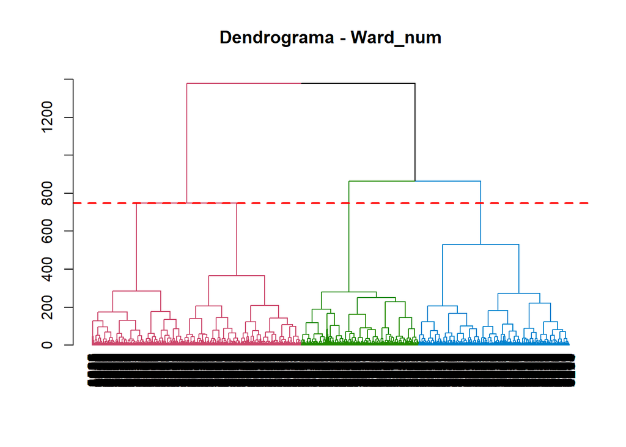

```r
plot_dendrogram_with_cut <- function(hclust_obj, method_name, k) {
  dend <- as.dendrogram(hclust_obj)
  dend <- color_branches(dend, k = k)
  plot(dend, main = paste("Dendrograma -", method_name))
  abline(h = hclust_obj$height[length(hclust_obj$height) - k + 1], col = "red", lwd = 2, lty = 2) # Línea roja indicando el corte
}

# Visualización para métodos numéricos
par(mfrow = c(1, 1)) # Coloca los gráficos en una fila con tres columnas
plot_dendrogram_with_cut(agrWard_num, "Ward_num", 3)
```